Faculty of Economic Sciences

Advanced programming in R - Academic year 2020/2021

5. Introduction to R Markdown.

# 2. Chunks in R Markdown

Piotr Ćwiakowski, Piotr Wójcik

25 marzec, 2021

# 1. Introduction

The biggest advantage of using Markdown within R Studio is its integration with other languages - R, Python, SQL and others. R studio gives to user abikity to (almost) automically includes coude outputs in their report. It is possible via code chunks. Code chunks can be inserted via button “Insert” in upper right corner of script window or simply using shortcut `ctrl + shift + I`. Example of chunks can be found below:

> ```{r}  
> `Here you write code you want to include`  
> ```

#### Chunk - example:

##### script.Rmd

> ```{r}  
> `x <- 2^3 + 2`  
> `y <- 2 + 3`  
> `x + y`  
> ```

##### document.html

```r
x <- 2^3 + 2
y <- 2 + 3
x + y
```

```
## [1] 15
```

# 2. Chunk options

Chunk have many options, which drives the way output is included in the report. User can define value of options in the header of each chunk (it can be done also globally, which we show later on). Let’s review the most frequentely used.

#### 2.1. Options: error, warning, message

By this group of options user can set whether errors, warnings and messges should be included in document. Let’s study examples:

##### script.Rmd

> ```{r}  
> `library(dplyr)`  
> ```

> ```{r error = F, warning = F, message = F}  
> `library(dplyr)`  
> ```

##### document.html

```r
library(dplyr)
library(dplyr)
```

#### 2.2. Options: echo, eval, include, comment, results

With this options we can decide if the code should be evaluated and whether code and/or result should be include in the documet (and how).

##### script.Rmd

Default behavior:

> ```{r}  
> `head(starwars)`  
> ```

`echo` parameter decides whether code will be includes:

> ```{r echo = F}  
> `head(starwars)`  
> ```

`eval` parameter decided whether code will be evaluated (interpreted):

> ```{r eval = F}  
> `head(starwars)`  
> ```

`include` decides whether evaluated code will be include in the document and output will be invisible:

> ```{r include = F}  
> `head(starwars)`  
> ```

Parameter `results` have 4 values:

- `markup` - prints results as in console (default value)
- `hide`- hides results
- `hold` - print results after the whole chunk
- `asis` - include result “as is” - useful if the output is raw HTML code (like in `kableExtra` or `xtable` packages)

> ```{r results = ‘markup’}  
> `head(starwars)`  
> ```

> ```{r results = ‘hide’}  
> `head(starwars)`  
> ```

> ```{r results = ‘hold’}  
> `head(starwars)`  
> ```

> ```{r results = ‘asis’}  
> `mean(starwars$height[starwars$name=="Luke Skywalker"])`  
> ```

##### document.html

Default behavior:

```r
head(starwars)
```

```
## # A tibble: 6 x 14
##   name     height  mass hair_color  skin_color eye_color birth_year sex   gender
##   <chr>     <int> <dbl> <chr>       <chr>      <chr>          <dbl> <chr> <chr>
## 1 Luke Sk~    172    77 blond       fair       blue            19   male  mascu~
## 2 C-3PO       167    75 <NA>        gold       yellow         112   none  mascu~
## 3 R2-D2        96    32 <NA>        white, bl~ red             33   none  mascu~
## 4 Darth V~    202   136 none        white      yellow          41.9 male  mascu~
## 5 Leia Or~    150    49 brown       light      brown           19   fema~ femin~
## 6 Owen La~    178   120 brown, grey light      blue            52   male  mascu~
## # ... with 5 more variables: homeworld <chr>, species <chr>, films <list>,
## #   vehicles <list>, starships <list>
```

`echo` parameter decides whether code will be includes:

```
## # A tibble: 6 x 14
##   name     height  mass hair_color  skin_color eye_color birth_year sex   gender
##   <chr>     <int> <dbl> <chr>       <chr>      <chr>          <dbl> <chr> <chr>
## 1 Luke Sk~    172    77 blond       fair       blue            19   male  mascu~
## 2 C-3PO       167    75 <NA>        gold       yellow         112   none  mascu~
## 3 R2-D2        96    32 <NA>        white, bl~ red             33   none  mascu~
## 4 Darth V~    202   136 none        white      yellow          41.9 male  mascu~
## 5 Leia Or~    150    49 brown       light      brown           19   fema~ femin~
## 6 Owen La~    178   120 brown, grey light      blue            52   male  mascu~
## # ... with 5 more variables: homeworld <chr>, species <chr>, films <list>,
## #   vehicles <list>, starships <list>
```

`eval` parameter decided whether code will be evaluated (interpreted):

```r
head(starwars)
```

Parameter `results` have 4 values:

- `markup` - prints results as in console (default value)
- `hide`- hides results
- `hold` - print results after the whole chunk
- `asis` - include result “as is” - useful if the output is raw HTML code (like in `kableExtra` or `xtable` packages)

```r
head(starwars)
```

```
# A tibble: 6 x 14
  name     height  mass hair_color  skin_color eye_color birth_year sex   gender
  <chr>     <int> <dbl> <chr>       <chr>      <chr>          <dbl> <chr> <chr>
1 Luke Sk~    172    77 blond       fair       blue            19   male  mascu~
2 C-3PO       167    75 <NA>        gold       yellow         112   none  mascu~
3 R2-D2        96    32 <NA>        white, bl~ red             33   none  mascu~
4 Darth V~    202   136 none        white      yellow          41.9 male  mascu~
5 Leia Or~    150    49 brown       light      brown           19   fema~ femin~
6 Owen La~    178   120 brown, grey light      blue            52   male  mascu~
# ... with 5 more variables: homeworld <chr>, species <chr>, films <list>,
#   vehicles <list>, starships <list>
```

```r
head(starwars)
```

```r
head(starwars)
```

```
## # A tibble: 6 x 14
##   name     height  mass hair_color  skin_color eye_color birth_year sex   gender
##   <chr>     <int> <dbl> <chr>       <chr>      <chr>          <dbl> <chr> <chr>
## 1 Luke Sk~    172    77 blond       fair       blue            19   male  mascu~
## 2 C-3PO       167    75 <NA>        gold       yellow         112   none  mascu~
## 3 R2-D2        96    32 <NA>        white, bl~ red             33   none  mascu~
## 4 Darth V~    202   136 none        white      yellow          41.9 male  mascu~
## 5 Leia Or~    150    49 brown       light      brown           19   fema~ femin~
## 6 Owen La~    178   120 brown, grey light      blue            52   male  mascu~
## # ... with 5 more variables: homeworld <chr>, species <chr>, films <list>,
## #   vehicles <list>, starships <list>
```

```r
mean(starwars$height[starwars$name=="Luke Skywalker"])
```

```
## [1] 172
```

```r
mean(starwars$height[starwars$name=="Luke Skywalker"])
```

[1] 172

## 2.3. Options of figure output

Because very often we want to render some figures in the output, there many options to configure details of a figure:

- `fig.align` - figure alignment (possible values are `left`, `right`, `center`)
- `fig.ext` - what should be extension of the file with figure
- `dev` - what engine (pdf, Cairopdf, png, bmp should be used for rendering)
- `dev.args` - gateway to pass additional parameters to render engine function (np. `dev.args=list(bg='yellow', pointsize=10)`)
- `dpi` - resolution of figure in dpi
- `fig.height` - height in inches
- `fig.width`- width in inches

### Example I

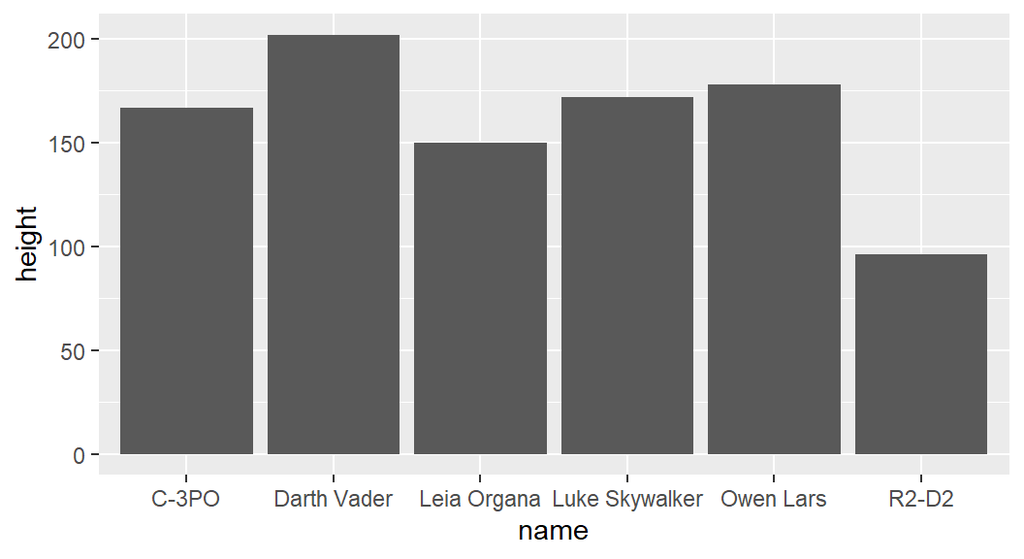

```r
# fig.align = 'left', fig.width=5.5, fig.height=3
ggplot(data = head(starwars), aes(x = name, y = height)) +
  geom_bar(stat = 'identity')
```

### Example II

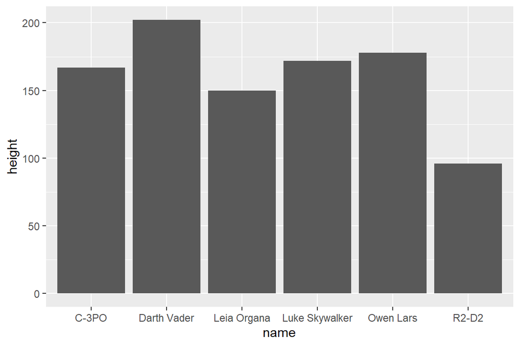

```r
# fig.align = 'right', fig.width=6, fig.height=4
ggplot(data = head(starwars), aes(x = name, y = height)) +
  geom_bar(stat = 'identity')
```

## 2.5. Caching

At the beginning, reports will knit quickly. However with increasing number of chunks, espescially with figures, time of knitting will increase substantially. On order to prevent it, you can cache chunk (save result after first knitting in external file). Chunk will be recomputed each time you change anything whithin the chunk. Chunk options which drives this feature is `cache`, which accepts values `TRUE` or `FALSE` (whether cache chunk or not). Additional chunk options, but not used so frequently, are: `cache.comments`, `cache.vars` , `cache.lazy`, `cache.path`, `dependson`.

Accepted practice is to cache chunks, when knitting last more than 5 seconds. Of course chunks with libraries and importing datasets shouldn’t be included.

> Exercise (NOT homework)

In order to understand `cache` option, please create a new R Markdown script and include several separate chunks with following code:

```
library(ggplot2)
data(diamonds)
ggplot(diamonds, aes(x = carat, y = price)) + geom_point()
```

Afterwards, compile document several times, first set option `cache=FALSE` and then change it to `TRUE`. Did document compile faster?

## 2.6. Inline chunk

Very useful feature is inline chunk. We can include result of the computation as part of the sentence, and therefore ensure to have always actual and correct numbers in the body of the report. For example consider following sentence in the report:

### script.Rmd

In analised dataset there are `'r nrow(diamonds)'` observations, and average price is `'r round(mean(diamonds$price), 2)'` USD.

### document.html

In analised dataset there are 53940 observations, and average price is 3932.8 USD.

## 2.7. Object `opts_chunk`

Because very often we want to set some chunk option globally, to save some time while defining them within each chunk, we can use special object in `knitr` package. This object is called `opts_chunk` and among others, consists method `set`, which allows to set parameters globally. Below there is example (notice, that it is usually placed at the beginning of the script).

```r
knitr::opts_chunk$set(cache = T,
                      fig.width = 7,
                      error = F,
                      message = F,
                      warning = F)
```

# 3. General rules of R Markdown

1. R session of R Studio is separated from R session launched for the purpose of document knitting.
2. Therefore, each library and each object needed for code in chunks should be imported at within rmd file.
3. Chunks share workspace, thus results computed in one chunks are available in following chunks.

# 4. Pretty output in chunks

Certain limitation of R chunks are rather simple outputs - like in R console. Significant improvement can be achieved with additional packages, like `kable()`.

```r
library(knitr)
data(diamonds)
head(diamonds) %>%
  kable()
```

| carat | cut | color | clarity | depth | table | price | x | y | z |
| --- | --- | --- | --- | --- | --- | --- | --- | --- | --- |
| 0.23 | Ideal | E | SI2 | 61.5 | 55 | 326 | 3.95 | 3.98 | 2.43 |
| 0.21 | Premium | E | SI1 | 59.8 | 61 | 326 | 3.89 | 3.84 | 2.31 |
| 0.23 | Good | E | VS1 | 56.9 | 65 | 327 | 4.05 | 4.07 | 2.31 |
| 0.29 | Premium | I | VS2 | 62.4 | 58 | 334 | 4.20 | 4.23 | 2.63 |
| 0.31 | Good | J | SI2 | 63.3 | 58 | 335 | 4.34 | 4.35 | 2.75 |
| 0.24 | Very Good | J | VVS2 | 62.8 | 57 | 336 | 3.94 | 3.96 | 2.48 |

Kable generates much better looking tables, let’s compare it with default output:

```r
data(diamonds)
head(diamonds)
```

```
## # A tibble: 6 x 10
##   carat cut       color clarity depth table price     x     y     z
##   <dbl> <ord>     <ord> <ord>   <dbl> <dbl> <int> <dbl> <dbl> <dbl>
## 1 0.23  Ideal     E     SI2      61.5    55   326  3.95  3.98  2.43
## 2 0.21  Premium   E     SI1      59.8    61   326  3.89  3.84  2.31
## 3 0.23  Good      E     VS1      56.9    65   327  4.05  4.07  2.31
## 4 0.290 Premium   I     VS2      62.4    58   334  4.2   4.23  2.63
## 5 0.31  Good      J     SI2      63.3    58   335  4.34  4.35  2.75
## 6 0.24  Very Good J     VVS2     62.8    57   336  3.94  3.96  2.48
```

On the other hand, package `stargazer` consists procedures to generate much more complicated tables (please notice while reading `.Rmd` file, that results option of the cunk is set to `asis`:

1. With descripive statistics from data.frame:

```r
# install.packages('stargazer')
library(stargazer)
stargazer(attitude, type =  "html")
```

| Statistic | N | Mean | St. Dev. | Min | Pctl(25) | Pctl(75) | Max |
| --- | --- | --- | --- | --- | --- | --- | --- |
| rating | 30 | 64.633 | 12.173 | 40 | 58.8 | 71.8 | 85 |
| complaints | 30 | 66.600 | 13.315 | 37 | 58.5 | 77 | 90 |
| privileges | 30 | 53.133 | 12.235 | 30 | 45 | 62.5 | 83 |
| learning | 30 | 56.367 | 11.737 | 34 | 47 | 66.8 | 75 |
| raises | 30 | 64.633 | 10.397 | 43 | 58.2 | 71 | 88 |
| critical | 30 | 74.767 | 9.895 | 49 | 69.2 | 80 | 92 |
| advance | 30 | 42.933 | 10.289 | 25 | 35 | 47.8 | 72 |

2. With regression results (one model):

```r
model <- lm(price ~ carat, data = diamonds)

stargazer(model, type = "html")
```

|  | *Dependent variable:* |
| --- | --- |
|  | price |
| carat | 7,756.426*** |
|  | (14.067) |
| Constant | -2,256.361*** |
|  | (13.055) |
| Observations | 53,940 |
| R<sup>2</sup> | 0.849 |
| Adjusted R<sup>2</sup> | 0.849 |
| Residual Std. Error | 1,548.562 (df = 53938) |
| F Statistic | 304,050.900*** (df = 1; 53938) |
| *Note:* | p<0.1; p<0.05; p<0.01 |

3. or with many models:

```r
model2 <- lm(price ~ carat + cut, data = diamonds)
model3 <- lm(price ~ carat + color, data = diamonds)

stargazer(model, model2, model3, type = "html")
```

|  | *Dependent variable:* |  |  |
| --- | --- | --- | --- |
|  | price |  |  |
|  | (1) | (2) | (3) |
| carat | 7,756.426*** | 7,871.082*** | 8,066.623*** |
|  | (14.067) | (13.980) | (14.040) |
| cut.L |  | 1,239.800*** |  |
|  |  | (26.100) |  |
| cut.Q |  | -528.598*** |  |
|  |  | (23.132) |  |
| cut.C |  | 367.910*** |  |
|  |  | (20.214) |  |
| cut4 |  | 74.594*** |  |
|  |  | (16.240) |  |
| color.L |  |  | -1,572.199*** |
|  |  |  | (22.318) |
| color.Q |  |  | -741.145*** |
|  |  |  | (20.399) |
| color.C |  |  | -122.696*** |
|  |  |  | (19.145) |
| color4 |  |  | 78.765*** |
|  |  |  | (17.583) |
| color5 |  |  | -144.740*** |
|  |  |  | (16.623) |
| color6 |  |  | -180.747*** |
|  |  |  | (15.078) |
| Constant | -2,256.361*** | -2,701.376*** | -2,702.233*** |
|  | (13.055) | (15.431) | (13.783) |
| Observations | 53,940 | 53,940 | 53,940 |
| R<sup>2</sup> | 0.849 | 0.856 | 0.864 |
| Adjusted R<sup>2</sup> | 0.849 | 0.856 | 0.864 |
| Residual Std. Error | 1,548.562 (df = 53938) | 1,511.458 (df = 53934) | 1,471.534 (df = 53932) |
| F Statistic | 304,050.900*** (df = 1; 53938) | 64,369.360*** (df = 5; 53934) | 48,930.850*** (df = 7; 53932) |
| *Note:* | p<0.1; p<0.05; p<0.01 |  |  |

# 5. Using external .R scripts and objects in reports

Very often report is result of hundreds of hours of work in R, which result in many scripts written in `.R` scripts which somewe want to include afterwards in `.Rmd` report. On the pther hand, we don’t want to double the analytical code in our report, espescially if it computes complicated and time consuming machine learning models. There are several ways to avoid code and computation duplication in `.Rmd` file.

1. With `load()` function you can qucikly load all necessary objects to the workspace.

[figure not shown]

```r
load('5a_example.Rdata')
w2
```

2. Sometimes, if you want to perform certain computation while knitting, but in the same time you want to avoid including whole code, because it’s very long and very uninteresting, you can just source this code:

[figure not shown]

```r
source('5a_example.R', encoding = 'UTF-8')
w2
```

```r
knitr::read_chunk('5b_example.R')
```

```r
1 + 1
```

```
## [1] 2
```

```r
x = rnorm(10)
```

```r
mean(x)
```

```
## [1] 0.03665818
```

```r
sd(x)
```

```
## [1] 0.8226403
```

# 6. Additional resources

The most comprehensive guide for chunk options is available here: https://yihui.org/knitr/options/

# 7. Homework

Prepare short R Markdown report (3 tables, 3 figures) using any available dataset. Until next classes, sent to mailbox pcwiakowski@wne.uw.edu.pl zip file with `.Rmd` file, dataset (if necessary) and output file (in format of your choice).